# heart_disease_classification

## Predicting the Presence of Heart Disease

##### By: Eshita Nandini

This dataset used is provided by The UCI Machine Learning Repository. In the version of the data I am using, there are only 14 attributes as they are commonly the ones preserved in past studies. Through this notebook, I try to predict the presence of heart disease by understanding the features present and solving a binary classification problem.

The challenge can be found here: https://www.kaggle.com/ronitf/heart-disease-uci

## I. Data Pre-Processing

```python
import pandas as pd
import numpy as np

#visualization libraries
import matplotlib.pyplot as plt
import seaborn as sns
%matplotlib inline

#build, train, test model ibraries
from sklearn.model_selection import train_test_split
from sklearn.linear_model import LogisticRegression
from sklearn.metrics import classification_report, confusion_matrix
from sklearn.tree import DecisionTreeClassifier
from sklearn.ensemble import RandomForestClassifier
from sklearn.model_selection import GridSearchCV
from sklearn.preprocessing import StandardScaler
```

```python
sns.set_style("whitegrid")
```

```python
import warnings
warnings.simplefilter(action='ignore', category=FutureWarning)
```

```python
heart = pd.read_csv('heart.csv')
```

I get an overview of the structure of the overall as well as information about possible null-values, data types, shape, distribution, etc.

```python
heart.shape
```

```
(303, 14)
```

```python
heart.head()
```

|  | age | sex | cp | trestbps | chol | fbs | restecg | thalach | exang | oldpeak | slope | ca | thal | target |
| --- | --- | --- | --- | --- | --- | --- | --- | --- | --- | --- | --- | --- | --- | --- |
| 0 | 63 | 1 | 3 | 145 | 233 | 1 | 0 | 150 | 0 | 2.3 | 0 | 0 | 1 | 1 |
| 1 | 37 | 1 | 2 | 130 | 250 | 0 | 1 | 187 | 0 | 3.5 | 0 | 0 | 2 | 1 |
| 2 | 41 | 0 | 1 | 130 | 204 | 0 | 0 | 172 | 0 | 1.4 | 2 | 0 | 2 | 1 |
| 3 | 56 | 1 | 1 | 120 | 236 | 0 | 1 | 178 | 0 | 0.8 | 2 | 0 | 2 | 1 |
| 4 | 57 | 0 | 0 | 120 | 354 | 0 | 1 | 163 | 1 | 0.6 | 2 | 0 | 2 | 1 |

```python
heart.info()
```

```
<class 'pandas.core.frame.DataFrame'>
RangeIndex: 303 entries, 0 to 302
Data columns (total 14 columns):
age         303 non-null int64
sex         303 non-null int64
cp          303 non-null int64
trestbps    303 non-null int64
chol        303 non-null int64
fbs         303 non-null int64
restecg     303 non-null int64
thalach     303 non-null int64
exang       303 non-null int64
oldpeak     303 non-null float64
slope       303 non-null int64
ca          303 non-null int64
thal        303 non-null int64
target      303 non-null int64
dtypes: float64(1), int64(13)
memory usage: 33.2 KB
```

There are no missing values in this set.

```python
heart.describe()
```

|  | age | sex | cp | trestbps | chol | fbs | restecg | thalach | exang | oldpeak | slope | ca | thal | target |
| --- | --- | --- | --- | --- | --- | --- | --- | --- | --- | --- | --- | --- | --- | --- |
| count | 303.000000 | 303.000000 | 303.000000 | 303.000000 | 303.000000 | 303.000000 | 303.000000 | 303.000000 | 303.000000 | 303.000000 | 303.000000 | 303.000000 | 303.000000 | 303.000000 |
| mean | 54.366337 | 0.683168 | 0.966997 | 131.623762 | 246.264026 | 0.148515 | 0.528053 | 149.646865 | 0.326733 | 1.039604 | 1.399340 | 0.729373 | 2.313531 | 0.544554 |
| std | 9.082101 | 0.466011 | 1.032052 | 17.538143 | 51.830751 | 0.356198 | 0.525860 | 22.905161 | 0.469794 | 1.161075 | 0.616226 | 1.022606 | 0.612277 | 0.498835 |
| min | 29.000000 | 0.000000 | 0.000000 | 94.000000 | 126.000000 | 0.000000 | 0.000000 | 71.000000 | 0.000000 | 0.000000 | 0.000000 | 0.000000 | 0.000000 | 0.000000 |
| 25% | 47.500000 | 0.000000 | 0.000000 | 120.000000 | 211.000000 | 0.000000 | 0.000000 | 133.500000 | 0.000000 | 0.000000 | 1.000000 | 0.000000 | 2.000000 | 0.000000 |
| 50% | 55.000000 | 1.000000 | 1.000000 | 130.000000 | 240.000000 | 0.000000 | 1.000000 | 153.000000 | 0.000000 | 0.800000 | 1.000000 | 0.000000 | 2.000000 | 1.000000 |
| 75% | 61.000000 | 1.000000 | 2.000000 | 140.000000 | 274.500000 | 0.000000 | 1.000000 | 166.000000 | 1.000000 | 1.600000 | 2.000000 | 1.000000 | 3.000000 | 1.000000 |
| max | 77.000000 | 1.000000 | 3.000000 | 200.000000 | 564.000000 | 1.000000 | 2.000000 | 202.000000 | 1.000000 | 6.200000 | 2.000000 | 4.000000 | 3.000000 | 1.000000 |

#### Attribute information:

This information was obtained from the Kaggle site:  
**age:** Age in years.  
**sex:** (1 = male; 0 = female)  
**cp:** Chest pain type (Value 1: typical angina, Value 2: atypical angina, Value 3: non-anginal pain, Value 4: asymptomatic)  
**trestbps:** Resting blood pressure (in mm Hg on admission to the hospital)  
**chol:** Serum cholesterol in mg/dl  
**fbs:** (fasting blood sugar > 120 mg/dl) (1 = true; 0 = false)  
**restecg:** Resting electrocardiographic measurement (0 = normal, 1 = having ST-T wave abnormality, 2 = showing probable or definite left ventricular hypertrophy by Estes' criteria)  
**thalach:** Maximum heart rate achieved  
**exang:** Exercise induced angina (1 = yes; 0 = no)  
**oldpeakST:** Depression induced by exercise relative to rest ('ST' relates to positions on the ECG plot)  
**slope:** The slope of the peak exercise ST segment  
**ca:** Number of major vessels (0-3) colored by flourosopy  
**thal:** 3 = normal; 6 = fixed defect; 7 = reversable defect (thalassemia - inherited blood disorder)  
**target:** 1 = has heart disease; 0 = doesn't have heart disease

```python
heart.dtypes
```

```
age           int64
sex           int64
cp            int64
trestbps      int64
chol          int64
fbs           int64
restecg       int64
thalach       int64
exang         int64
oldpeak     float64
slope         int64
ca            int64
thal          int64
target        int64
dtype: object
```

From the Attribute Information, it is clear that not all of them should be integers/floats which appears to be the case when I check the data types. This needs to be corrected as well as categorical values should be given labels for correspoonding values.

The section below was obtained from a Kernel and is useful in this analysis.

```python
heart['sex']=heart['sex'].replace([1,0], ['Male', 'Female'])
heart['slope']=heart['slope'].replace([0,1,2], ['Upsloping','Flat','Down-Sloping'])
heart['restecg']=heart['restecg'].replace([0,1,2], ['Normal', 'Abnormality','Hypertrophy'])
heart['exang']=heart['exang'].replace([1,0], ['Yes', 'No'])
heart['fbs']=heart['fbs'].replace([1,0], ['Yes', 'No'])
heart['thal']=heart['thal'].replace([1,2,3], ['Normal', 'Fixed Defect','Reversible Defect'])
heart['cp']=heart['cp'].replace([0,1,2,3], ['Typical Angina', 'Atypical Angina','Non-Anginal Pain','Asymptomatic Pain'])
```

```python
heart['sex']=heart['sex'].astype('object')
heart['cp']=heart['cp'].astype('object')
heart['thal']=heart['thal'].astype('object')
heart['fbs']=heart['fbs'].astype('object')
heart['exang']=heart['exang'].astype('object')
heart['restecg']=heart['restecg'].astype('object')
heart['slope']=heart['slope'].astype('object')
```

```python
heart.dtypes
```

```
age           int64
sex          object
cp           object
trestbps      int64
chol          int64
fbs          object
restecg      object
thalach       int64
exang        object
oldpeak     float64
slope        object
ca            int64
thal         object
target        int64
dtype: object
```

Categorical variables are cast as 'object' datatypes and I double-check that this change was made. In the next section, I take a closer look at the variables and understand the relationship between them.

## II. Exploratory Data Analysis

### Categorical Variables

```python
heart['target'].value_counts()
```

```
1    165
0    138
Name: target, dtype: int64
```

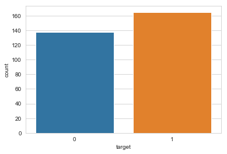

```python
sns.countplot('target', data=heart)
```

About 54% of the data includes patients with heart disease (target = 1) and about 46% don't (target = 0). This is quite a close split between the two so there might not be too many problems due to this distribution, but recall that we don't have a large dataset n = 303.

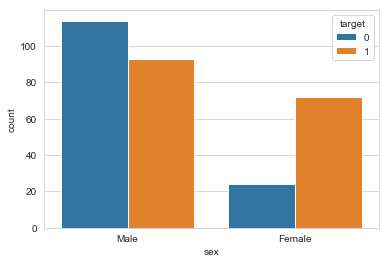

```python
sns.countplot('sex', hue='target', data=heart)
```

It appears that there is a closer split of heart disease vs. no heart disease in males than there are in female patients. This may mean that we do not get that great of a prediction of heart disease in females because we do not have the equality of samples like we do from male patients. There are only about ~25 patients in this dataset which are female without heart disease.

```
target               0   1
cp
Asymptomatic Pain    7  16
Atypical Angina      9  41
Non-Anginal Pain    18  69
Typical Angina     104  39
```

```
Text(0,0.5,'Percentage')
```

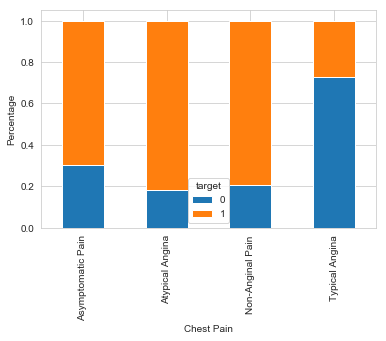

```python
tab = pd.crosstab(heart['cp'], heart['target'])
print (tab)

tab.div(tab.sum(1).astype(float), axis=0).plot(kind="bar", stacked=True)
plt.xlabel('Chest Pain')
plt.ylabel('Percentage')
```

Angina is a type of chest pain caused by reduced blood flow to the heart; there are four types of angina in our data and it can also be a symptom of coronary artery disease. While exploring the Chest Pain Type (cp) variable, it appears that a presence of 'Typical Angina' may mean usually mean for an absence of heart disease, which is not the case with 'Atypical' and 'Non-Anginal' pain.

```
sex                Female  Male
cp
Asymptomatic Pain       4    19
Atypical Angina        18    32
Non-Anginal Pain       35    52
Typical Angina         39   104
```

```
Text(0,0.5,'Percentage')
```

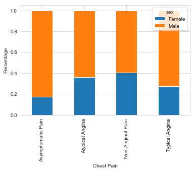

```python
tab = pd.crosstab(heart['cp'], heart['sex'])
print (tab)

tab.div(tab.sum(1).astype(float), axis=0).plot(kind="bar", stacked=True)
plt.xlabel('Chest Pain')
plt.ylabel('Percentage')
```

From the data, males tend to be the group that experiences anginal pain with more than 80% of the group having 'Asymptotic' (silent) pain.

```
target   0    1
exang
No      62  142
Yes     76   23
```

```
Text(0,0.5,'Percentage')
```

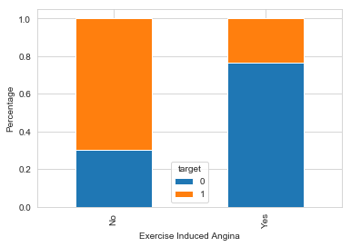

```python
tab = pd.crosstab(heart['exang'], heart['target'])
print (tab)

tab.div(tab.sum(1).astype(float), axis=0).plot(kind="bar", stacked=True)
plt.xlabel('Exercise Induced Angina')
plt.ylabel('Percentage')
```

It appears that commonly, in cases with Exercise Induced Angina (exang) present, there is less of a chance of the existence of heart disease, which is the opposite case for non-Exercise induced Angina. This makes sense when exercising, there is a greater demand for oxygen and the heart works harder and angina can occur.

```
target        0   1
restecg
Abnormality  56  96
Hypertrophy   3   1
Normal       79  68
```

```
Text(0,0.5,'Percentage')
```

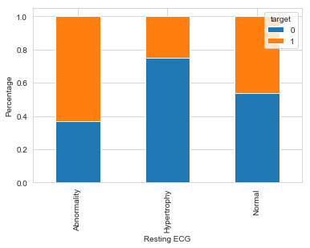

```python
tab = pd.crosstab(heart['restecg'], heart['target'])
print (tab)

tab.div(tab.sum(1).astype(float), axis=0).plot(kind="bar", stacked=True)
plt.xlabel('Resting ECG')
plt.ylabel('Percentage')
```

Abnormality refers to electrocardiographic (ECG) ST-T wave abnormality and we see that there may need to be additional attention given to patients with this. Hypertropy here refers to the enlargement or thickening of the heart's main pumping chamber (left ventricle), but we only have 4 patients for this so it is a little difficult to understand the true nature of this based off the data I have. 'Normal' patients show almost an even split of the target.

### Continuous Variables

```python
cont_var = heart[['age', 'trestbps', 'chol', 'thalach', 'oldpeak', 'ca' ]]
```

```python
cont_var.head()
```

|  | age | trestbps | chol | thalach | oldpeak | ca |
| --- | --- | --- | --- | --- | --- | --- |
| 0 | 63 | 145 | 233 | 150 | 2.3 | 0 |
| 1 | 37 | 130 | 250 | 187 | 3.5 | 0 |
| 2 | 41 | 130 | 204 | 172 | 1.4 | 0 |
| 3 | 56 | 120 | 236 | 178 | 0.8 | 0 |
| 4 | 57 | 120 | 354 | 163 | 0.6 | 0 |

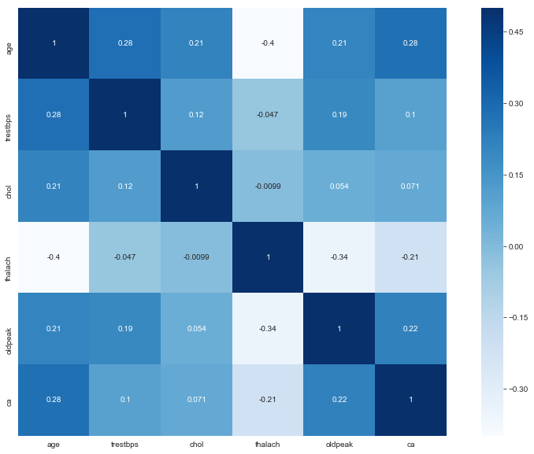

```python
plt.figure(figsize=(16,10))
sns.heatmap(cont_var.corr(), vmax=0.5, square=True, annot=True, cmap = 'Blues')
```

There are no heavily correlated continuous variables so there is no reason to fear multicollinearity in the data so all variables will be kept. The highest positive correlation we see are between:

ca (Number of major blood vessels) vs. Age (0.28) and trestbps (Resting Blood Pressure) vs. Age (0.28)

We usually know that blood pressure does raise with age so this correlation makes sense, but 28% is a smaller number than I personally expected. I would generally expected the number of blood vessels to become less prominent with age. With the other variables, again, there are correlations but they are not incredibly high.

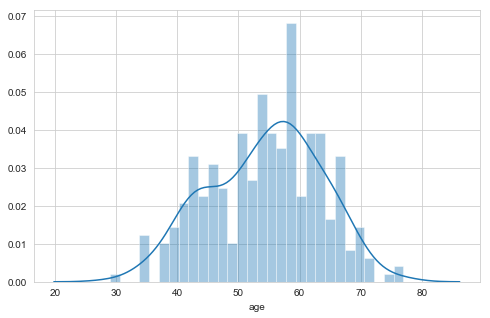

```python
plt.figure(figsize=(8,5))
sns.distplot(heart['age'], kde=True, bins=30)
```

It appears that most of our data comes from the age group between ~50 to ~65.

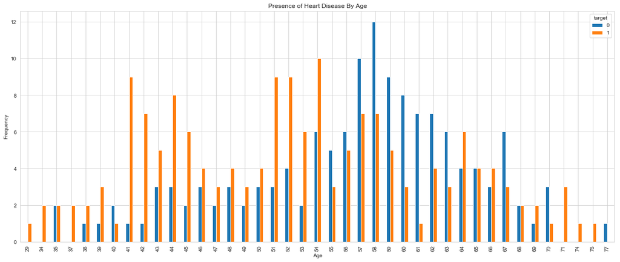

```python
pd.crosstab(heart['age'],heart['target']).plot(kind="bar",figsize=(20,8))
plt.title('Presence of Heart Disease By Age')
plt.xlabel('Age')
plt.ylabel('Frequency')
plt.show()
```

It appears that there is more data on people with heart disease compared to those without it prior to 55 years of age. After that age group, there are more people with no heart disease compared to those who do.

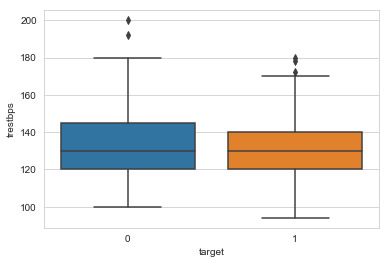

```python
sns.boxplot(x='target', y='trestbps', data=heart)
```

```
Text(0,0.5,'Maximum Heart Rate Acheieved by Person')
```

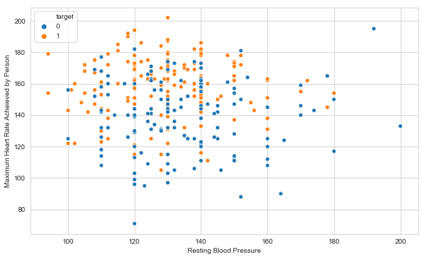

```python
plt.figure(figsize=(10,6))
sns.scatterplot(x='trestbps',y='thalach', hue='target',data=heart)
plt.xlabel('Resting Blood Pressure')
plt.ylabel('Maximum Heart Rate Acheieved by Person')
```

People with heart disease tend to spread on the left side of the graph with higher maximum heart rate achieved, while those who don't have heart disease appear to spread on the side with higher resting blood presure. Those two blue points on the right side of the plot could possibly be outliers.

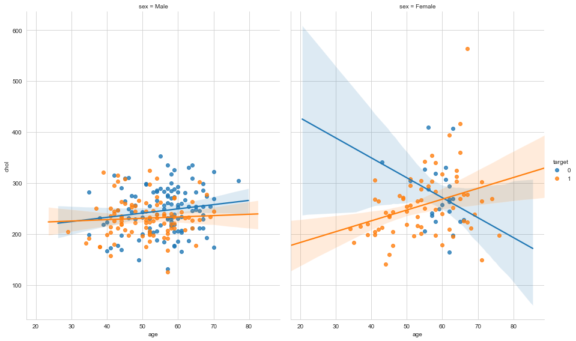

```python
sns.lmplot(x='age', y='chol', data=heart, col='sex', hue='target', aspect = 0.8, height=8)
```

In this simple linear regression by split by target, we see that the female plot is a lot more spread out. This could be due to the possible outlier heart disease point which could be influencing the line. Recall that there were significantly less females without heart disease in our dataset, which is leading to an obvious negative line. In the male plot, we see the points a lot more concentrated with both the lines almost flat. This means that age does not directly mean increase in cholesterol and in turn, heart disease.

## III. Classification Models

I employ three classification models with grid search: logistic, decision tree, and a random forest. I will evaluate each of them by the corresponding confusion matrix and discuss the results at the end.

#### Assign Dummy Values to Categorical Features

```python
heart = pd.get_dummies(heart, drop_first=True)
```

#### Create Test + Train Split

```python
X = heart.drop('target', axis=1)
y = heart['target']
```

```python
X_train, X_test, y_train, y_test = train_test_split(X, y, test_size=0.3, random_state=42)
```

#### Scale Data

```python
scaler = StandardScaler()

#train set
X_train_scaled = scaler.fit_transform(X_train)
X_train = pd.DataFrame(X_train_scaled)


#test set
X_test_scaled = scaler.transform(X_test)
X_test = pd.DataFrame(X_test_scaled)
```

### 1. Logistic Regression

```python
logmodel = LogisticRegression()
```

```python
#create parameter list for grid search
param_grid = {'penalty':['l1','l2'],
         'C':[0.01,0.1,1,10,100],
         'class_weight':['balanced',None]}

grid = GridSearchCV(logmodel,param_grid,cv=10)
```

```python
grid.fit(X_train, y_train)
```

```
GridSearchCV(cv=10, error_score='raise-deprecating',
       estimator=LogisticRegression(C=1.0, class_weight=None, dual=False, fit_intercept=True,
          intercept_scaling=1, max_iter=100, multi_class='warn',
          n_jobs=None, penalty='l2', random_state=None, solver='warn',
          tol=0.0001, verbose=0, warm_start=False),
       fit_params=None, iid='warn', n_jobs=None,
       param_grid={'penalty': ['l1', 'l2'], 'C': [0.01, 0.1, 1, 10, 100], 'class_weight': ['balanced', None]},
       pre_dispatch='2*n_jobs', refit=True, return_train_score='warn',
       scoring=None, verbose=0)
```

```python
grid.best_params_
```

```
{'C': 0.1, 'class_weight': None, 'penalty': 'l2'}
```

```python
log_pred = grid.predict(X_test)
```

#### Logistic Regression - Results

```python
print(confusion_matrix(y_test, log_pred))
```

```
[[34  7]
 [ 7 43]]
```

From the Confusion Matrix, we get the following:

**True Positives (TP):** correctly predicted heart disease  
43

**True Negatives (TN):** correctly predicted that they don't have heart disease  
34

**False Positives (FP):** incorrectly predicted that they do have heart disease ("Type I error")  
7

**False Negatives (FN):** incorrectly predicted that they don't have heart disease ("Type II error")  
7

Here are a few things I will use to understand the performance of this regression:

**Classification Accuracy**: This is how well the model did at predicting the correct label (target = 1 or target = 0).

**Misclassification (Error) Rate**: This is how many times the model predicted incorrectly.

**Sensitivity (Recall)**: When the actual value is positive, how often the prediction is correct.

**Specificity**: When actual value is negative, how often is the prediction correct.

```python
print('Classification Accuracy: ', ((confusion_matrix(y_test, log_pred)[0][0] +
                    confusion_matrix(y_test, log_pred)[1][1])/len(y_test)))


print('Misclassification (Error Rate): ',((confusion_matrix(y_test, log_pred)[0][1] +
                                               confusion_matrix(y_test, log_pred)[1][0])/len(y_test)))


print('Sensitivity: ',(confusion_matrix(y_test, log_pred)[1][1] /
                            (confusion_matrix(y_test, log_pred)[1][0] + confusion_matrix(y_test, log_pred)[1][1])))


print('Specificity: ',(confusion_matrix(y_test, log_pred)[0][0] /
                        (confusion_matrix(y_test, log_pred)[0][0] + confusion_matrix(y_test, log_pred)[0][1])))
```

```
Classification Accuracy:  0.8461538461538461
Misclassification (Error Rate):  0.15384615384615385
Sensitivity:  0.86
Specificity:  0.8292682926829268
```

### 2. Decision Tree

```python
dtree = DecisionTreeClassifier()
```

```python
#create parameter list for grid search
param_grid = {'max_features': ['auto', 'sqrt', 'log2'],
          'min_samples_split': [2,3,4,5,6,7,8,9,10,11,12,13,14,15],
          'min_samples_leaf':[1,2,3,4,5,6,7,8,9,10,11]}
tree_model = GridSearchCV(dtree, param_grid, n_jobs=-1)
```

```python
tree_model.fit(X_train,y_train)
```

```
GridSearchCV(cv='warn', error_score='raise-deprecating',
       estimator=DecisionTreeClassifier(class_weight=None, criterion='gini', max_depth=None,
            max_features=None, max_leaf_nodes=None,
            min_impurity_decrease=0.0, min_impurity_split=None,
            min_samples_leaf=1, min_samples_split=2,
            min_weight_fraction_leaf=0.0, presort=False, random_state=None,
            splitter='best'),
       fit_params=None, iid='warn', n_jobs=-1,
       param_grid={'max_features': ['auto', 'sqrt', 'log2'], 'min_samples_split': [2, 3, 4, 5, 6, 7, 8, 9, 10, 11, 12, 13, 14, 15], 'min_samples_leaf': [1, 2, 3, 4, 5, 6, 7, 8, 9, 10, 11]},
       pre_dispatch='2*n_jobs', refit=True, return_train_score='warn',
       scoring=None, verbose=0)
```

```python
tree_model.best_params_
```

```
{'max_features': 'auto', 'min_samples_leaf': 9, 'min_samples_split': 2}
```

#### Prediction + Evaluation

```python
tree_pred = tree_model.predict(X_test)
```

```python
print('Classification Accuracy: ', ((confusion_matrix(y_test, tree_pred)[0][0] +
                    confusion_matrix(y_test, tree_pred)[1][1])/len(y_test)))


print('Misclassification (Error Rate): ',((confusion_matrix(y_test, tree_pred)[0][1] +
                                               confusion_matrix(y_test, tree_pred)[1][0])/len(y_test)))


print('Sensitivity: ',(confusion_matrix(y_test, tree_pred)[1][1] /
                            (confusion_matrix(y_test, tree_pred)[1][0] + confusion_matrix(y_test, tree_pred)[1][1])))


print('Specificity: ',(confusion_matrix(y_test, tree_pred)[0][0] /
                        (confusion_matrix(y_test, tree_pred)[0][0] + confusion_matrix(y_test, tree_pred)[0][1])))
```

```
Classification Accuracy:  0.8351648351648352
Misclassification (Error Rate):  0.16483516483516483
Sensitivity:  0.86
Specificity:  0.8048780487804879
```

### 3. Random Forest

Recall that n = 303, which means this dataset is quite small. I expect that the random forest to perform only slightly better than the decision tree.

```python
rfc = RandomForestClassifier()
```

```python
#create parameter list for grid search
param_grid = [{
        'max_depth': np.arange(1, 10),
        'min_samples_split': np.arange(2, 5),
        'random_state': [3],
        'n_estimators': np.arange(10, 20)
    },]
forest_model = GridSearchCV(rfc, param_grid, n_jobs=-1)
```

```python
forest_model.fit(X_train, y_train)
```

```
GridSearchCV(cv='warn', error_score='raise-deprecating',
       estimator=RandomForestClassifier(bootstrap=True, class_weight=None, criterion='gini',
            max_depth=None, max_features='auto', max_leaf_nodes=None,
            min_impurity_decrease=0.0, min_impurity_split=None,
            min_samples_leaf=1, min_samples_split=2,
            min_weight_fraction_leaf=0.0, n_estimators='warn', n_jobs=None,
            oob_score=False, random_state=None, verbose=0,
            warm_start=False),
       fit_params=None, iid='warn', n_jobs=-1,
       param_grid=[{'max_depth': array([1, 2, 3, 4, 5, 6, 7, 8, 9]), 'min_samples_split': array([2, 3, 4]), 'random_state': [3], 'n_estimators': array([10, 11, 12, 13, 14, 15, 16, 17, 18, 19])}],
       pre_dispatch='2*n_jobs', refit=True, return_train_score='warn',
       scoring=None, verbose=0)
```

```python
forest_model.best_params_
```

```
{'max_depth': 8, 'min_samples_split': 2, 'n_estimators': 13, 'random_state': 3}
```

#### Prediction + Evaluation

```python
rfc_pred = forest_model.predict(X_test)
```

```python
print('Classification Accuracy: ', ((confusion_matrix(y_test, rfc_pred)[0][0] +
                    confusion_matrix(y_test, rfc_pred)[1][1])/len(y_test)))


print('Misclassification (Error Rate): ',((confusion_matrix(y_test, rfc_pred)[0][1] +
                                               confusion_matrix(y_test, rfc_pred)[1][0])/len(y_test)))


print('Sensitivity: ',(confusion_matrix(y_test, rfc_pred)[1][1] /
                            (confusion_matrix(y_test, rfc_pred)[1][0] + confusion_matrix(y_test, rfc_pred)[1][1])))


print('Specificity: ',(confusion_matrix(y_test, rfc_pred)[0][0] /
                        (confusion_matrix(y_test, rfc_pred)[0][0] + confusion_matrix(y_test, rfc_pred)[0][1])))
```

```
Classification Accuracy:  0.8461538461538461
Misclassification (Error Rate):  0.15384615384615385
Sensitivity:  0.84
Specificity:  0.8536585365853658
```

## IV. Evaluation + Conclusion

It appeared the logistic regression and the random forest yielded the highest Classification Accuracy (84.6%) as well as lowest Error Rate (15.4%). However, in terms of Specificity, the random forest performs better by about 2%, but the logistic model is about 2% more Sensitive. It is difficult to pick an optimal model at this point and further insight will lead to a better pick. With the next steps of my journey with ML, I want to get familiar with feature importance tools and apply that to upcoming data analysis projects. From the conclusion of this one, I gained insight into the process of proper machine learning from picking up data, cleaning, etc. More interestingly, I found out that predictors like age and cholesterol are not direct indicators of heart disease. I hope to continue with working with health data in the future and expect to become more acquainted with model explanability which is something I didn't delve into completely.